# Top Games on Play Store EDA and Algorithms

## Plots and Models

### Table of Game Categories With Their Frequency

```
##           Categories Freq
## 1        GAME ACTION  100
## 2     GAME ADVENTURE  100
## 3        GAME ARCADE  100
## 4         GAME BOARD  100
## 5          GAME CARD  124
## 6        GAME CASINO   99
## 7        GAME CASUAL  100
## 8   GAME EDUCATIONAL   99
## 9         GAME MUSIC   95
## 10       GAME PUZZLE  100
## 11       GAME RACING  100
## 12 GAME ROLE PLAYING  100
## 13   GAME SIMULATION  100
## 14       GAME SPORTS  100
## 15     GAME STRATEGY  100
## 16       GAME TRIVIA   91
## 17         GAME WORD  104
```

> As we can see out of 1712 most amount of the top-rated games are in the genre of Card and Word. The trivia type of games is the least rated genre. I also created a barplot of this table.

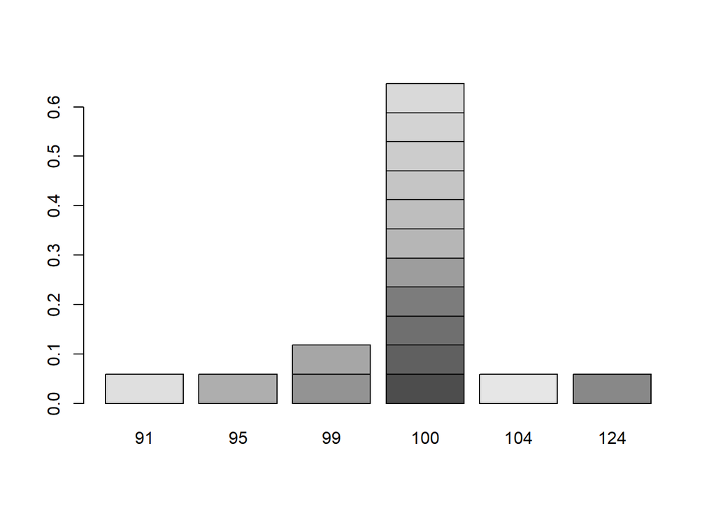

### Pie Chart of The Game Types

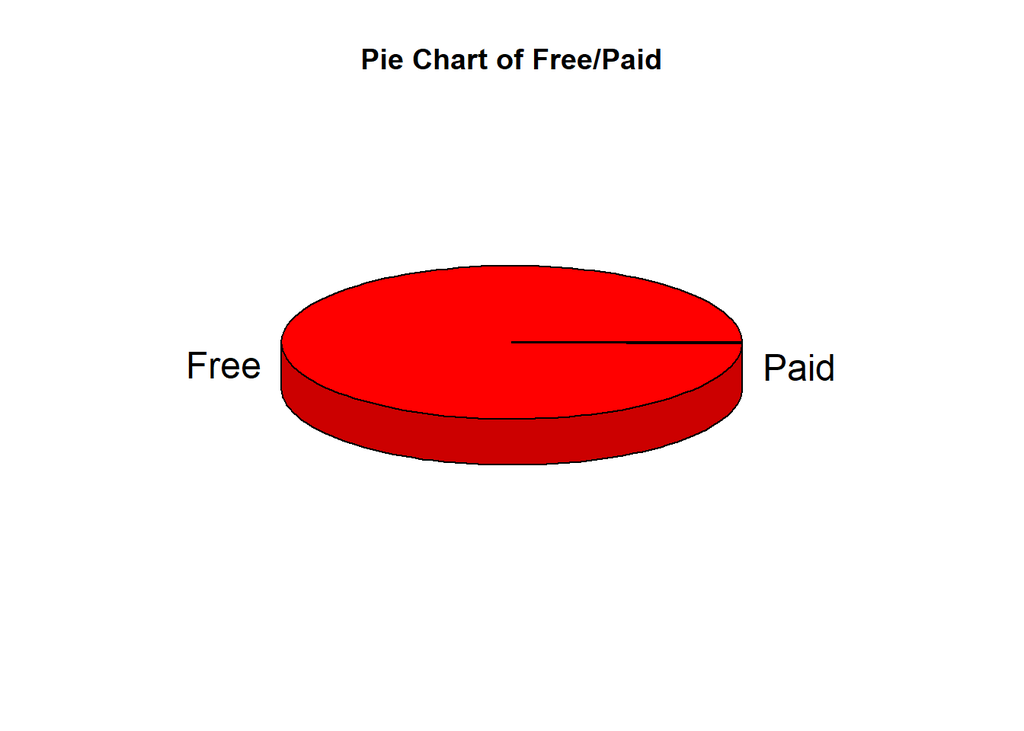

> We can see from the pie chart that a very small amount of paid games makes it to the top charts. Plans like free or freemium can be considered by developers since users do not want to pay big amounts for mobile games. Developers earn more with free games and it is more profitable to collect revenue with ads.

### Boxplot With Average Rating and Installs

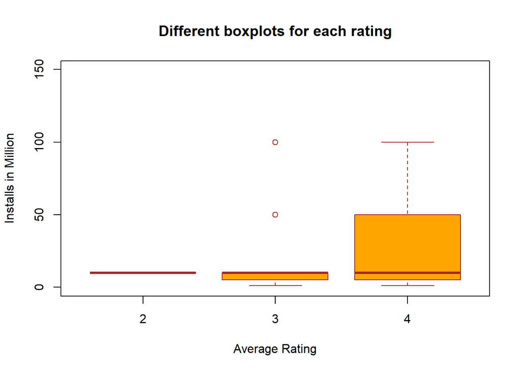

> According to this boxplot as the install count increase average rating of the game increases which should be expected. All ratings median is somewhat in same value but average rating 4 has the biggest interquartile range.

## Regression Models

```r
storedata <- storedata %>%
  mutate(paid = replace(paid, paid == "True", 1))
storedata <- storedata %>%
  mutate(paid = replace(paid, paid == "False", 0))

storedata$paid <-  as.numeric(storedata$paid)

storedata_2 <- storedata[c(2:14)]
```

> To get better results in my OLS assumptions and other regression models I converted paid variable to a dummy variable with 1’s and 0’s and removed the names of the games from the dataset. Let’s see how our plot looks like.

```r
lm.fit <- lm(formula = installs  ~ . , data = train)
summary(lm.fit)
```

```
##
## Call:
## lm(formula = installs ~ ., data = train)
##
## Residuals:
##     Min      1Q  Median      3Q     Max
## -250.64  -11.10   -4.48    6.20  361.96
##
## Coefficients:
##                            Estimate Std. Error t value Pr(>|t|)
## (Intercept)               2.514e+01  1.666e+01   1.509  0.13161
## total.ratings             3.755e-05  1.392e-05   2.698  0.00710 **
## average.rating           -3.150e+00  4.127e+00  -0.763  0.44543
## growth..30.days.         -1.043e-05  1.559e-04  -0.067  0.94666
## growth..60.days.          6.076e-05  4.436e-04   0.137  0.89108
## price                    -1.400e+01  8.236e+00  -1.700  0.08941 .
## categoryGAME ADVENTURE   -1.538e+01  5.339e+00  -2.880  0.00407 **
## categoryGAME ARCADE       9.506e+00  5.351e+00   1.777  0.07594 .
## categoryGAME BOARD        1.568e+00  5.407e+00   0.290  0.77186
## categoryGAME CARD        -5.312e+00  5.187e+00  -1.024  0.30605
## categoryGAME CASINO      -1.271e+01  5.439e+00  -2.337  0.01963 *
## categoryGAME CASUAL      -1.018e+01  5.305e+00  -1.919  0.05528 .
## categoryGAME EDUCATIONAL  1.118e-01  5.438e+00   0.021  0.98360
## categoryGAME MUSIC       -6.136e+00  5.504e+00  -1.115  0.26518
## categoryGAME PUZZLE      -5.179e+00  5.596e+00  -0.926  0.35489
## X5.star.ratings          -9.545e-06  1.437e-05  -0.664  0.50654
## X4.star.ratings          -2.062e-04  3.935e-05  -5.240 1.96e-07 ***
## X3.star.ratings           2.201e-04  1.240e-04   1.775  0.07622 .
## X2.star.ratings           1.673e-03  1.771e-04   9.449  < 2e-16 ***
## X1.star.ratings          -4.244e-04  2.489e-05 -17.052  < 2e-16 ***
## paid                      5.897e+00  3.803e+01   0.155  0.87681
## ---
## Signif. codes:  0 '***' 0.001 '**' 0.01 '*' 0.05 '.' 0.1 ' ' 1
##
## Residual standard error: 36.84 on 979 degrees of freedom
## Multiple R-squared:  0.7329, Adjusted R-squared:  0.7274
## F-statistic: 134.3 on 20 and 979 DF,  p-value: < 2.2e-16
```

### Predictor Effect Plot

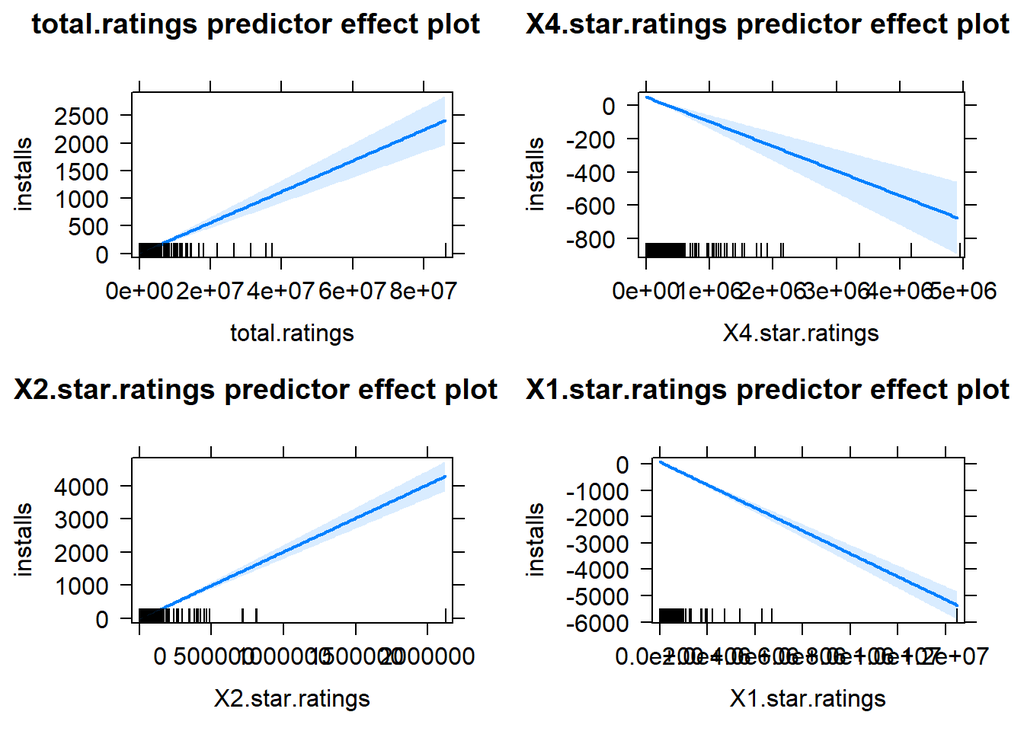

*Effect of the rating observations in the dataset to the installs can be analyzed from predictor effect plot.*

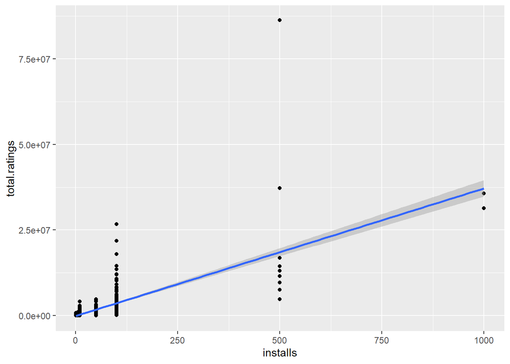

***